# Practical Machine Learning Project

Oliver Paisley

September 27, 2015

## Executive Summary

We are going to be creating a machine learning algorithm to predict the manner in which exercises were performed. The training data for this project are available [here](https://d396qusza40orc.cloudfront.net/predmachlearn/pml-training.csv). The test data are available [here](https://d396qusza40orc.cloudfront.net/predmachlearn/pml-testing.csv).

## Data Processing

We will break up the training set into two subsets. One will be called `sub_train`, and one will be called `validate`. We will train our model on `sub_train`, and then use it to predict values to compare to the `validate` set. This gives us a dataset to test on (`validate`) while leaving the true test set alone.

```r
train <- read.csv("pml-training.csv",
                  na.strings = c("", "NA", "NULL"))
test  <- read.csv("pml-testing.csv",
                  na.strings = c("", "NA", "NULL"))

remove_these_cols <- sapply(train, function(x) sum(is.na(x)) / nrow(train)) > 0.9

train <- train[ , !remove_these_cols]
test  <- test[ , !remove_these_cols]

# Removing columns 1 through 6, as they do not hold any valuable information.
train <- train[ , -(1:6)]
test  <- test[ , -(1:6)]

library(caret)
set.seed(1234)

data_part <- createDataPartition(train$classe,
                                 p = 0.3,
                                 list = FALSE)

sub_train <- train[data_part, ]
validate  <- train[-data_part, ]
```

## Random Forest Model Fitting

We will then fit a random forest model using classe as the outcome variable, and all other variables as predictor variables. There is no need to do cross validation with random forests. From [here](http://www.stat.berkeley.edu/~breiman/RandomForests/cc_home.htm#ooberr):

> In random forests, there is no need for cross-validation or a separate test set to get an unbiased estimate of the test set error. It is estimated internally, during the run, as follows: Each tree is constructed using a different bootstrap sample from the original data. About one-third of the cases are left out of the bootstrap sample and not used in the construction of the kth tree. Put each case left out in the construction of the kth tree down the kth tree to get a classification. In this way, a test set classification is obtained for each case in about one-third of the trees. At the end of the run, take j to be the class that got most of the votes every time case n was oob. The proportion of times that j is not equal to the true class of n averaged over all cases is the oob error estimate. This has proven to be unbiased in many tests.

Therefore, we can create a simple and satisfactory random forest model with the following code.

```r
library(randomForest)
```

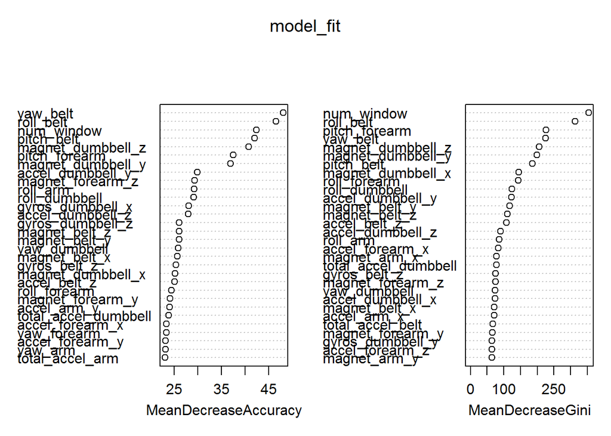

```r
set.seed(1234)

model_fit <- randomForest(classe ~ .,
                   data = sub_train,
                   importance = TRUE)

varImpPlot(model_fit)
```

```r
confusionMatrix(predict(model_fit, validate), validate$classe)
```

```
## Confusion Matrix and Statistics
##
##           Reference
## Prediction    A    B    C    D    E
##          A 3906   26    0    3    0
##          B    0 2601   19    0    0
##          C    0   30 2370   48    7
##          D    0    0    6 2200   21
##          E    0    0    0    0 2496
##
## Overall Statistics
##
##                Accuracy : 0.9883
##                  95% CI : (0.9864, 0.9901)
##     No Information Rate : 0.2844
##     P-Value [Acc > NIR] : < 2.2e-16
##
##                   Kappa : 0.9853
##  Mcnemar's Test P-Value : NA
##
## Statistics by Class:
##
##                      Class: A Class: B Class: C Class: D Class: E
## Sensitivity            1.0000   0.9789   0.9896   0.9773   0.9889
## Specificity            0.9970   0.9983   0.9925   0.9976   1.0000
## Pos Pred Value         0.9926   0.9927   0.9654   0.9879   1.0000
## Neg Pred Value         1.0000   0.9950   0.9978   0.9956   0.9975
## Prevalence             0.2844   0.1935   0.1744   0.1639   0.1838
## Detection Rate         0.2844   0.1894   0.1726   0.1602   0.1818
## Detection Prevalence   0.2865   0.1908   0.1788   0.1622   0.1818
## Balanced Accuracy      0.9985   0.9886   0.9910   0.9875   0.9945
```

We can see that the accuracy of our model, when run on the `validate` set, is 0.9883, or 98.83%. The out of sample error rate is 1 minus this value.

Thus, the *out of sample error rate* is 0.0117, or 1.17%.

## Predicting the Test Set

The last step in this proejct is running our algorithm on the test set and submitting our results. This is quite straight forward.

```r
answers <- predict(model_fit,
                   test)

pml_write_files = function(x){
  n = length(x)
  for(i in 1:n){
    filename = paste0("problem_id_",i,".txt")
    write.table(x[i],file=filename,quote=FALSE,row.names=FALSE,col.names=FALSE)
  }
}

pml_write_files(answers)
```